# CFS Network Analysis

# Step 1: Load in the data

Because the CFS data set is of such a large size, we’ll use a package that is used to help deal with larger than average datasets.

```r
library(data.table)
```

```r
df <- fread("~/Desktop/CDUP/2012_cfs.txt", data.table = FALSE)
```

```
##
Read 0.0% of 4547661 rows
Read 21.8% of 4547661 rows
Read 42.0% of 4547661 rows
Read 61.1% of 4547661 rows
Read 80.7% of 4547661 rows
Read 4547661 rows and 20 (of 20) columns from 0.350 GB file in 00:00:08
```

# Step 2: Aggregate Data by Shipment route

Now, since we have the data loaded, we want to collect the data by shipping route between two separate locations. Once again, since we are working with a larger than average, we will use the plyr and dplyr packages as they are suited to performing data frame transformations on a large scale.

```r
library(plyr)
library(dplyr)
```

In the dplyr code below, we are using a piping mechanism (%>%). The easiest way to interpret this mechanism is that it takes the output of a previous line of code and makes in the input for the following line. Therefore, in this example, we take our original data frame, and that becomes the input for the mutate command below. The resulting data frame from the mutate command becaomes the input for the group_by command and so on.

```r
edge_list <- df %>%
  # Create unique columns for location
  mutate(ORIG = paste(ORIG_STATE, ORIG_MA, ORIG_CFS_AREA, sep = "|"),
         DEST = paste(DEST_STATE, DEST_MA, DEST_CFS_AREA, sep = "|")) %>%
  # Group the data by shipping route
  group_by(ORIG, DEST) %>%
  # Calculate summaries of each shipping route
  summarize(n_shipments = n(), # number of shipments in dataset
            weight = mean(SHIPMT_WGHT), # average weight
            value = mean(SHIPMT_VALUE), # average value
            distance = mean(SHIPMT_DIST_ROUTED)) # average distance
```

Because the data frame is still large, let’s get a sense for how the number of shipments between destinations is distributed.

```r
library(ggplot2)
```

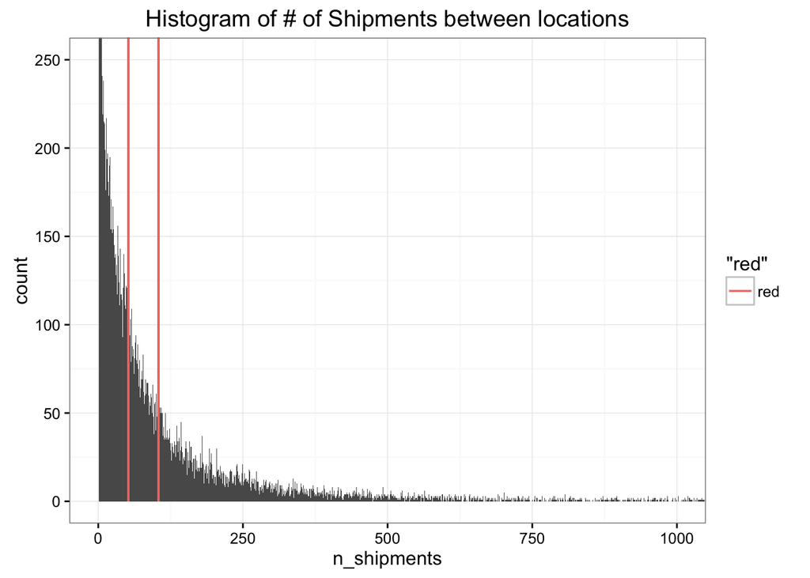

```r
ggplot(edge_list, aes(x=n_shipments)) +
  geom_histogram(binwidth = 1) +
  ggtitle("Histogram of # of Shipments between locations") +
  theme_bw() +
  coord_cartesian(xlim = c(0,1000), ylim = c(0,250)) +
  geom_segment(aes(x = 52, y = 0, xend = 52, yend = max(edge_list$n_shipments), color = 'red')) +
  geom_segment(aes(x = 104, y = 0, xend = 104, yend = max(edge_list$n_shipments), color = 'red'))
```

We can see that there are a large number of shipping routes with very low levels of shipping. For our purposes, initially, we will subset to use only those routes with more than 52 shipments throughout the survey.

```r
edge_list1 <- edge_list[edge_list$n >= 52,]
```

# Create a Network Object

Now comes time to make the network object. For this part, we will utilize R’s network analysis package: igraph.

```r
library(igraph)
graph <- graph_from_data_frame(edge_list1, directed = TRUE)
```

# Plot the network

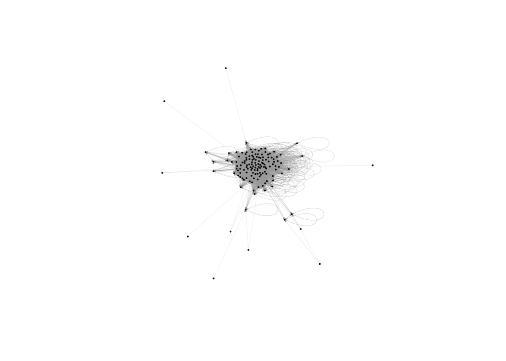

```r
plot.igraph(graph, vertex.size = 1,
            vertex.label = NA,
            edge.width = log(E(graph)$n_shipments)/40,
            edge.arrow.size = 0.1)
```

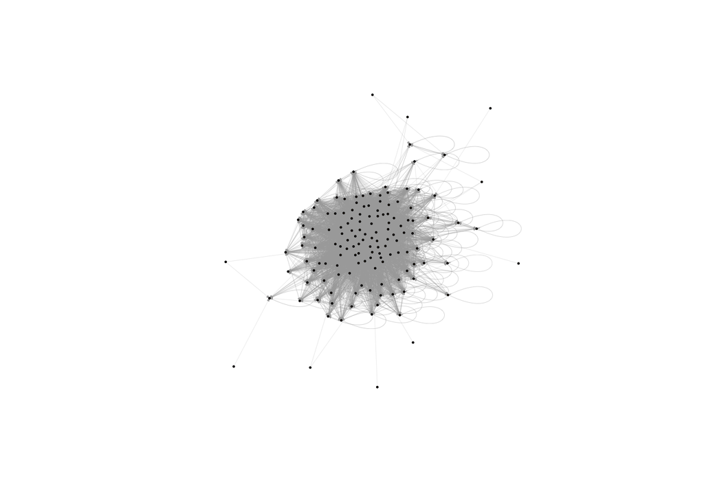

```r
plot.igraph(graph, vertex.size = 1,
            vertex.label = NA,
            layout = layout.lgl(graph),
            edge.width = log(E(graph)$n_shipments)/40,
            edge.arrow.size = 0.1)
```